# Homework: Build a StationXML Inventory for recent KSC deployment

Seven USF stations were deployed at Kennedy Space Center between January 7-12, 2026.

- Each features a Nanometrics Centaur digitizer, and a Nanometrics Trillium Compact Post-Hole 120-s seismometer.
- This is the same equipment we setup in our class a few weeks ago - except we also had infrasound.

Three additional seismic stations were setup by Marshall Space Flight Center, using Guralp and Silicon Audio equipment. You can ignore those for this exercise - or potentially earn some bonus points if you find responses for those too!

## Goal

Create a valid **StationXML** file for this small network using:

- Station coordinates stored in an **Excel** file
- Instrument responses pulled from the **IRIS Nominal Response Library (NRL)**

You will:

1. Load the station list with **pandas** into a pandas DataFrame
2. Create a Response object for a USF Nanometrics station
3. Build an ObsPy **Inventory**
4. Write out a **StationXML** file

> We're keeping it simple: one network, three channels per station (Z, N, E), same equipment at each site.

**Warning:** only attempt this homework after you have completed this week's reading exercises (notebooks 73 and 74)

## Provided file

Your station list is in:

- `Summary_Seismic_Station_List.xlsx`

One column contains photos — **ignore it**.

An alternative version of the Excel file is also provided as a Comma-Separated-Variable (CSV) text file, just in case you cannot read the Excel file. This is easier to read.

(If you open any Excel file with Excel, you can save it as a CSV).

## Make sure you have openpyxl installed in your conda environment!

This is required to read Excel files. CSV files will work without it.

```python
import sys
!conda install -y openpyxl --prefix {sys.prefix}
```

[output not shown]

## Minimal pandas intro (what you need today)

**pandas** is a Python library for working with tables (“dataframes”).  
For this homework you only need to:

- read an Excel file
- select a few columns
- loop over rows

**Note**: you may need to install openpyxl in conda, and then restart this notebook/kernel. At the command line:

```
conda activate compsci # or whatever your conda env is
conda install openpyxml
```

```python
import pandas as pd

xlsx_path = r"Summary_Seismic_Station_List.xlsx"
df = pd.read_excel(xlsx_path)

df.head(10)
```

|  | Site Name | GPS Coordinates | Photo | lat | lon | Notes | Digitizer | Seismometer | Infrasound |
| --- | --- | --- | --- | --- | --- | --- | --- | --- | --- |
| 0 | B01 | 28°37'17"N 80°36'24"W | NaN | 28.621389 | -80.606667 | Seismic (nanometrics) #271. Infrasound (other)... | Centaur (271) | NaN | infraBSU (268, 412, 453) |
| 1 | B03 | 28°38'34"N 80°37'25"W | NaN | 28.642778 | -80.623611 | Sensor ~100ft from Eagle 4 tower on dune. Seis... | NaN | Trillium C-PH120 (2663) | infraBSU (417) |
| 2 | B05 | 28°38'24"N 80°38'42"W | NaN | 28.640000 | -80.645000 | Sensor in front of Helipad 9 sign. Seismic (na... | Centaur (386) | Trillium C-PH120 (2392) | infraBSU (414) |
| 3 | B07 | 28°36'26"N 80°35'39"W | NaN | 28.607222 | -80.594167 | Sensor (Guralp) #00B68. IPv4 169.254.168.11 | Certimus (00B68) | NaN | NaN |
| 4 | B12 | 28°37'18"N 80°38'50"W | NaN | 28.621667 | -80.647222 | Sensor located off Happy Creek Rd. Guralp Cert... | Certimus (00D68) | NaN | NaN |
| 5 | B14 | 28°37'56"N 80°36'57"W | NaN | 28.632222 | -80.615833 | Seismic (nanometrics) #2719. Infrasound x3 - #... | Centaur (383) | Trillium C-PH120 (2719) | infraBSU (292, 461, 336) |
| 6 | B20 | 28°34'25"N 80°34'20"W | NaN | 28.573611 | -80.572222 | Sensor located 20 ft 195degrees from north. Se... | Centaur (384) | NaN | M25 (071975), infraBSU (403) |
| 7 | B23 | 28°34'43"N 80°36'28"W | NaN | 28.578611 | -80.607778 | Sensor (gain set to 5 Vpp). SA #the only one w... | NaN | Silicon Audio | NaN |
| 8 | B24 | 28°34'50"N 80°38'27"W | NaN | 28.580556 | -80.640833 | Seismic (nanometrics) #2619. Infrasound #0224.... | Centaur (166) | Trillium C-PH120 (2619) | infraBSU (224) |
| 9 | B29 | 28°37'05"N 80°40'37"W | NaN | 28.618056 | -80.676944 | Site of controlled burn. Station watered to sa... | Centaur (202) | Trillium C-PH120 (2410) | infraBSU (436) |

If for any reason you cannot load the Excel file, you can try the CSV file instead:

```
df = pd.read_csv("Summary_Seismic_Station_List.csv")
```

```python
df.columns
```

```
Index(['Site Name', 'GPS Coordinates', 'Photo', 'lat', 'lon', 'Notes',
       'Digitizer', 'Seismometer', 'Infrasound'],
      dtype='object')
```

## Step 1 — Keep only the columns we need

For StationXML, we need at minimum:

- station code (name)
- latitude
- longitude

We will also keep:

- seismometer model (if present)
- digitizer model (if present)

```python
use_cols = ["Site Name", "lat", "lon", "Seismometer", "Digitizer"]
stations = df[use_cols].copy()

# Ignore the Photo column (already excluded)
stations
```

|  | Site Name | lat | lon | Seismometer | Digitizer |
| --- | --- | --- | --- | --- | --- |
| 0 | B01 | 28.621389 | -80.606667 | NaN | Centaur (271) |
| 1 | B03 | 28.642778 | -80.623611 | Trillium C-PH120 (2663) | NaN |
| 2 | B05 | 28.640000 | -80.645000 | Trillium C-PH120 (2392) | Centaur (386) |
| 3 | B07 | 28.607222 | -80.594167 | NaN | Certimus (00B68) |
| 4 | B12 | 28.621667 | -80.647222 | NaN | Certimus (00D68) |
| 5 | B14 | 28.632222 | -80.615833 | Trillium C-PH120 (2719) | Centaur (383) |
| 6 | B20 | 28.573611 | -80.572222 | NaN | Centaur (384) |
| 7 | B23 | 28.578611 | -80.607778 | Silicon Audio | NaN |
| 8 | B24 | 28.580556 | -80.640833 | Trillium C-PH120 (2619) | Centaur (166) |
| 9 | B29 | 28.618056 | -80.676944 | Trillium C-PH120 (2410) | Centaur (202) |

## Step 2 — Create a Response object for a USF Nanometrics station

```python
# TO DO: code for Response object for USF Nanometrics station from NRL
from obspy.clients.nrl import NRL

nrl=NRL()

usf_stations = df[~df['Digitizer'].str.contains('Certimus', na=False) &
                  ~df['Seismometer'].str.contains('Silicon Audio', na=False)]

sensor_keys = ["Nanometrics", "Trillium Compact 120 (Vault, Posthole, OBS)", "754 V/m/s"]
datalogger_keys = ["Nanometrics", "Centaur", "40 Vpp (1)", "Off", "Linear phase", "500"]


resp= nrl.get_response(datalogger_keys=datalogger_keys, sensor_keys=sensor_keys)

for index, row in usf_stations.iterrows():
    print(f"Processing station: {row['Site Name']}")
```

```
Processing station: B01
Processing station: B03
Processing station: B05
Processing station: B14
Processing station: B20
Processing station: B24
Processing station: B29
```

## Step 3 - Create an ObsPy Inventory

The Inventory object should contain a list of 1 Network object.

The Network object should have a network code, description, and start_date, and contain a list of 7 Station objects.

Each Station object should have a station code, description, and coordinates, and a list of 3 Channel objects.

Each Channel object should have a channel code, a location code, coordinates (StationXML repeats them), depth, and sampling rate, and a Response object.

```python
# TO DO: Here is some starter code for the Inventory object. You will need to update it with station metadata from the Excel file and Response metadata from NRL.

from obspy.core.inventory import Inventory, Network, Station, Channel, Site
from obspy import UTCDateTime

# -----------------------------
# Network-level metadata
# -----------------------------
NETWORK_CODE = "1R"
NETWORK_DESCRIPTION = "KSC Seismic Network"
START_DATE = UTCDateTime(2026, 7, 1)    # TODO: update - this is not correct. it should be the date of the first station installation

# -----------------------------
# Channel metadata
# -----------------------------
CHANNEL_CODES = ["CHZ", "CHN", "CHE"]   # Google "SEED channel naming"
LOC_CODE = ""                           # usually blank unless multiple sensors
FS = 500.0                              # sample rate (Hz)
ELEV_M = 0.0                            # good enough - KSC is close to sea level
DEPTH_M = 0.75                          # burial depth (m) - holes were 2-3 feet deep
SENSOR = "Nanometrics Trillium C-PH 120"
DIGITIZER = "Nanometrics Centaur"

# Create Response object for USF Nanometrics station from NRL

resp = nrl.get_response(datalogger_keys=datalogger_keys, sensor_keys=sensor_keys)

# Loop over rows in DataFrame - one row per station ("site name" is the station code)

stations = []
for index, row in usf_stations.iterrows():
    sta_code = row["Site Name"]

    # Loop over CHANNEL_CODES and create a Channel object for each one.

    channels = []
    for chan_code in CHANNEL_CODES:

        # fill in - create a new Channel object - make sure to include the Response object you created above
        # append to channels list

      chao = Channel(
            code = chan_code,
            location_code = LOC_CODE,
            latitude = row["lat"],
            longitude = row["lon"],
            elevation = ELEV_M,
            depth = DEPTH_M,
            sample_rate = FS,
            start_date = START_DATE
        )
      chao.response = resp
      channels.append(chao)

    # fill in - create new Station object
    # append to stations list

    stao = Station(
        code = sta_code,
        latitude = row["lat"],
        longitude = row["lon"],
        elevation = ELEV_M,
        creation_date = START_DATE
    )

    stao.channels = channels
    stations.append(stao)

# Create a Network object and add the stations to it. Then create an Inventory object and add the network to it.

network = Network(
    code = NETWORK_CODE,
    description = NETWORK_DESCRIPTION,
    stations = stations,
    start_date = START_DATE
)
inventory = Inventory(networks=[network], source = "KSC Seismic Network")

print(inventory)
```

```
Inventory created at 2026-03-08T21:10:30.356943Z
	Created by: ObsPy 1.4.2
		    https://www.obspy.org
	Sending institution: KSC Seismic Network
	Contains:
		Networks (1):
			1R
		Stations (7):
			1R.B01 ()
			1R.B03 ()
			1R.B05 ()
			1R.B14 ()
			1R.B20 ()
			1R.B24 ()
			1R.B29 ()
		Channels (21):
			1R.B01..CHZ, 1R.B01..CHN, 1R.B01..CHE, 1R.B03..CHZ, 1R.B03..CHN,
			1R.B03..CHE, 1R.B05..CHZ, 1R.B05..CHN, 1R.B05..CHE, 1R.B14..CHZ,
			1R.B14..CHN, 1R.B14..CHE, 1R.B20..CHZ, 1R.B20..CHN, 1R.B20..CHE,
			1R.B24..CHZ, 1R.B24..CHN, 1R.B24..CHE, 1R.B29..CHZ, 1R.B29..CHN,
			1R.B29..CHE
```

## Step 4 — Build Inventory, plot, and write StationXML

```
Inventory created at 2026-03-08T21:10:35.329613Z
	Created by: ObsPy 1.4.2
		    https://www.obspy.org
	Sending institution: KSC Seismic Network
	Contains:
		Networks (1):
			1R
		Stations (7):
			1R.B01 ()
			1R.B03 ()
			1R.B05 ()
			1R.B14 ()
			1R.B20 ()
			1R.B24 ()
			1R.B29 ()
		Channels (21):
			1R.B01..CHZ, 1R.B01..CHN, 1R.B01..CHE, 1R.B03..CHZ, 1R.B03..CHN,
			1R.B03..CHE, 1R.B05..CHZ, 1R.B05..CHN, 1R.B05..CHE, 1R.B14..CHZ,
			1R.B14..CHN, 1R.B14..CHE, 1R.B20..CHZ, 1R.B20..CHN, 1R.B20..CHE,
			1R.B24..CHZ, 1R.B24..CHN, 1R.B24..CHE, 1R.B29..CHZ, 1R.B29..CHN,
			1R.B29..CHE
```

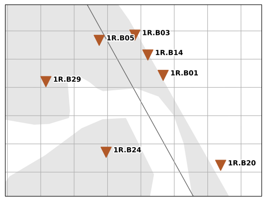

```
Inventory written to KSC_Seismic_Network.xml
```

```python
# TO DO

from obspy.core.inventory import Inventory

# fill in - create Inventory object and add Network object to it

network = Network(
    code = NETWORK_CODE,
    description = NETWORK_DESCRIPTION,
    stations = stations,
    start_date = START_DATE
)

from obspy.core.inventory import Inventory
inv = Inventory(networks=[network], source="KSC Seismic Network")

print (inv)
inv.plot(projection="local", level="station")
inv.write("KSC_Seismic_Network.xml", format="STATIONXML")
print("Inventory written to KSC_Seismic_Network.xml")
```

## Step 5 — Quick check: read back the StationXML

```python
from obspy import read_inventory

inv2 = read_inventory(out_xml)
print(inv2)
```

```
Inventory created at 2026-03-08T21:10:35.329613Z
	Created by: ObsPy 1.4.2
		    https://www.obspy.org
	Sending institution: KSC Seismic Network
	Contains:
		Networks (1):
			1R
		Stations (7):
			1R.B01 ()
			1R.B03 ()
			1R.B05 ()
			1R.B14 ()
			1R.B20 ()
			1R.B24 ()
			1R.B29 ()
		Channels (21):
			1R.B01..CHZ, 1R.B01..CHN, 1R.B01..CHE, 1R.B03..CHZ, 1R.B03..CHN,
			1R.B03..CHE, 1R.B05..CHZ, 1R.B05..CHN, 1R.B05..CHE, 1R.B14..CHZ,
			1R.B14..CHN, 1R.B14..CHE, 1R.B20..CHZ, 1R.B20..CHN, 1R.B20..CHE,
			1R.B24..CHZ, 1R.B24..CHN, 1R.B24..CHE, 1R.B29..CHZ, 1R.B29..CHN,
			1R.B29..CHE
```

## What to submit

Submit your notebook **and** the generated StationXML file.

### Your short note (2–4 sentences)

At the end of your notebook, include a short note:

- Which stations successfully got responses from the NRL?
- Which stations did not, and why (missing mapping, missing instrument info, etc.)?

# add notes below...

1. Because the goal was to get the stations with the Nanometrics Centaur digitizer and Nanometrics Trillium Compact Post-Hole 120-s seismometer, the seven stations out of 10 successfully got resonses from the NRL.
2. The stations that did not get picked up from the NRL were the stations using the Guralp and Silicon Audio equipment. In one of the first cells I excluded the stations/digitizers that contained Certiumus and Silicon Audio. When ignoring those lines of code, all of the stations end up having responses and showing up on the map and read back into the inventory.